# Final Exam

Ben Pelczynski

2024-12-12

## Problem Statement

I am attempting to determine how the demographic features and time period impact amount the engagement on VisageTome. Specifically, I will use a fitted model to determine if and how the age, gender, and nationality of a user can impact the amount of minutes they spend on the platform, as well as if and how the comtemporary time of day and day of the week has an impact on the platform. I will also be analyzing the model’s ability to detect the presence of super-users, and if any useful insights can be gleaned from their presence.

## Approach

As the outcome variable MinPerBlock is measuring a discrete count of events over a period time, I have to decided to fit it to a hierarchical Poisson distibution. The model formula will assign a coefficient to the feature of gender, age, nationality, day_of_week, and time_of_day; additionally, the demographic features (age, gender, and nationality) will be hierachically grouped by their corresponding user.

## Prior Rationale

In order to maximize the impact of the data on the posterior distribution, I have selected the uninformative prior $N(0,1000)$ for the regression coefficient means, and the uninformative prior $Cauchy(0,5)$ (also known as the Half Cauchy prior) for the coefficient and error variances.

## Findings

```r
library(brms)
library(tidyverse)
data = read.csv("DS6040F24_finaldat.csv")

fit <- brm(
formula = MinPerBlock ~ day_of_week + time_of_day + gender + age + nationality + (1 + gender + age + nationality | user_id),
data = data,
family = poisson(),
prior = c(set_prior("normal(0, 1000)", class = "b"), set_prior("cauchy(0, 5)", class = "sd")),
chains = 2,
iter = 2000,
warmup = 1000,
seed = 123
)
summary(fit)
```

```
##  Family: poisson
##   Links: mu = log
## Formula: MinPerBlock ~ day_of_week + time_of_day + gender + age + nationality + (1 + gender + age + nationality | user_id)
##    Data: data (Number of observations: 4200)
##   Draws: 2 chains, each with iter = 2000; warmup = 1000; thin = 1;
##          total post-warmup draws = 2000
##
## Multilevel Hyperparameters:
## ~user_id (Number of levels: 100)
##                                                      Estimate Est.Error
## sd(Intercept)                                            0.30      0.04
## sd(genderMale)                                           0.14      0.10
## sd(age)                                                  0.00      0.00
## sd(nationalityCarthaginian)                              0.13      0.11
## sd(nationalityFirstNations)                              0.15      0.10
## sd(nationalityHolyRoman)                                 0.20      0.14
## sd(nationalityRoman)                                     0.17      0.13
## cor(Intercept,genderMale)                               -0.35      0.33
## cor(Intercept,age)                                      -0.07      0.36
## cor(genderMale,age)                                     -0.02      0.36
## cor(Intercept,nationalityCarthaginian)                  -0.27      0.34
## cor(genderMale,nationalityCarthaginian)                 -0.01      0.35
## cor(age,nationalityCarthaginian)                        -0.02      0.35
## cor(Intercept,nationalityFirstNations)                  -0.24      0.33
## cor(genderMale,nationalityFirstNations)                  0.01      0.35
## cor(age,nationalityFirstNations)                        -0.04      0.36
## cor(nationalityCarthaginian,nationalityFirstNations)     0.11      0.36
## cor(Intercept,nationalityHolyRoman)                     -0.05      0.33
## cor(genderMale,nationalityHolyRoman)                     0.00      0.35
## cor(age,nationalityHolyRoman)                           -0.01      0.35
## cor(nationalityCarthaginian,nationalityHolyRoman)        0.03      0.36
## cor(nationalityFirstNations,nationalityHolyRoman)        0.01      0.35
## cor(Intercept,nationalityRoman)                         -0.17      0.36
## cor(genderMale,nationalityRoman)                         0.03      0.36
## cor(age,nationalityRoman)                               -0.04      0.35
## cor(nationalityCarthaginian,nationalityRoman)            0.07      0.37
## cor(nationalityFirstNations,nationalityRoman)            0.05      0.36
## cor(nationalityHolyRoman,nationalityRoman)               0.04      0.34
##                                                      l-95% CI u-95% CI Rhat
## sd(Intercept)                                            0.23     0.38 1.01
```

[output cut: 79 more lines]

```
## day_of_weekThursday         1622
## day_of_weekTuesday          1356
## day_of_weekWednesday        1295
## time_of_dayMidday           1706
## time_of_dayMorning          1407
## genderMale                  1007
## age                         1122
## nationalityCarthaginian      951
## nationalityFirstNations     1081
## nationalityHolyRoman         819
## nationalityRoman            1073
##
## Draws were sampled using sampling(NUTS). For each parameter, Bulk_ESS
## and Tail_ESS are effective sample size measures, and Rhat is the potential
## scale reduction factor on split chains (at convergence, Rhat = 1).
```

```r
user_intercepts <- data.frame(ranef(fit)$user_id[, , "Intercept"])
user_intercepts <- user_intercepts %>% mutate(User = rownames(user_intercepts)) %>% arrange(desc(user_intercepts$Estimate))

head(aggregate(x= data$MinPerBlock, by = list(data$user_id), FUN = mean) %>% arrange(desc(x)), 10)
```

```
##    Group.1        x
## 1       40 327.3095
## 2       15 323.5238
## 3       45 300.2143
## 4       89 298.8333
## 5       33 297.0238
## 6       67 295.9524
## 7       80 280.5238
## 8       64 277.6905
## 9       29 271.7619
## 10      49 264.2143
```

```r
head(user_intercepts, 10)
```

```
##     Estimate Est.Error        Q2.5     Q97.5 User
## 76 0.4791477 0.2278246 -0.09221589 0.8621575   76
## 6  0.4459504 0.2080786 -0.07064442 0.7967424    6
## 9  0.4082447 0.2521940 -0.20771237 0.8040824    9
## 24 0.3902652 0.2132427 -0.15146987 0.7342207   24
## 13 0.3707808 0.1949600 -0.12281485 0.7054460   13
## 78 0.3534544 0.2138424 -0.21754570 0.6923315   78
## 40 0.3498310 0.2199698 -0.16509284 0.7351068   40
## 50 0.3303048 0.2056773 -0.16963343 0.6785282   50
## 58 0.2962211 0.1895090 -0.17620409 0.5878627   58
## 94 0.2912929 0.1884247 -0.17391252 0.6081772   94
```

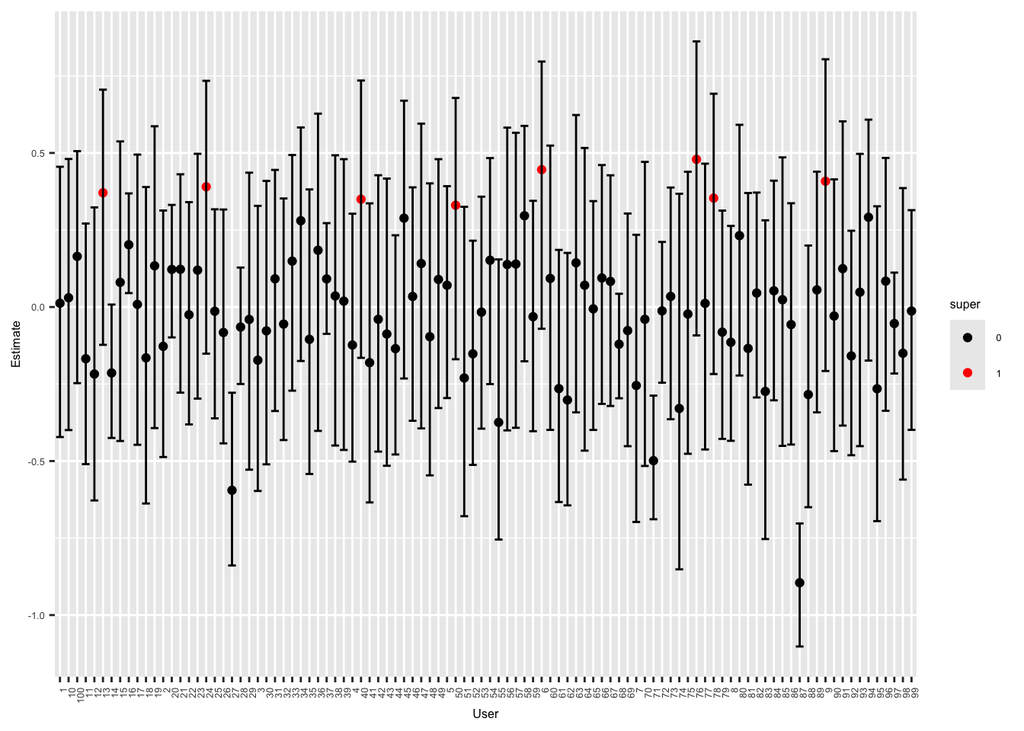

```r
user_intercepts$super <- ifelse(user_intercepts$Estimate > 0.3, "1", "0")

ggplot(user_intercepts, aes(x = User, y = Estimate)) + geom_point(aes(colour = super)) + geom_errorbar(aes(ymin = Q2.5, ymax = Q97.5)) + theme(text = element_text(size = 6), axis.text.x = element_text(angle = 90, hjust = 1)) + scale_color_manual(values = c("black", "red"))
```

## Summary

My criteria for defining the “super users” of the platform is primarily based on looking at their average level of engagement while controlling for demographic information (in other words, the users who are using the platform much more often than other individuals in their demographic group). I am also secondarily considering the users’ absolute average MinPerBlock. Based on this criteria, the super users of the platform in this dataset are:

- User 76, a 57-year-old Carthaginian Female.
- User 6, a 42-year-old Atlantian Male.
- User 9, a 57-year-old Holy Roman Female.
- User 24, a 54-year-old First Nations Female.
- User 13, a 47-year-old Carthaginian Female.
- User 78, an 85-year-old Atlantian Male.
- User 40, an 111-year-old Atlantian Male, who is especially notable for also having the highest absolute average MinPerBlock.
- User 50, a 49-year-old First Nations Female.

## Diagnostics

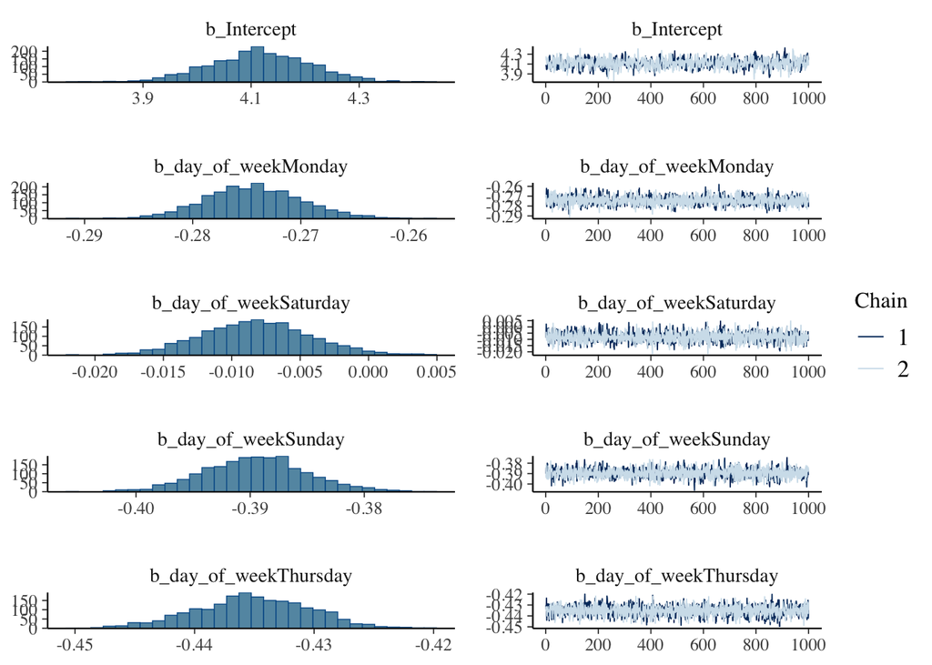

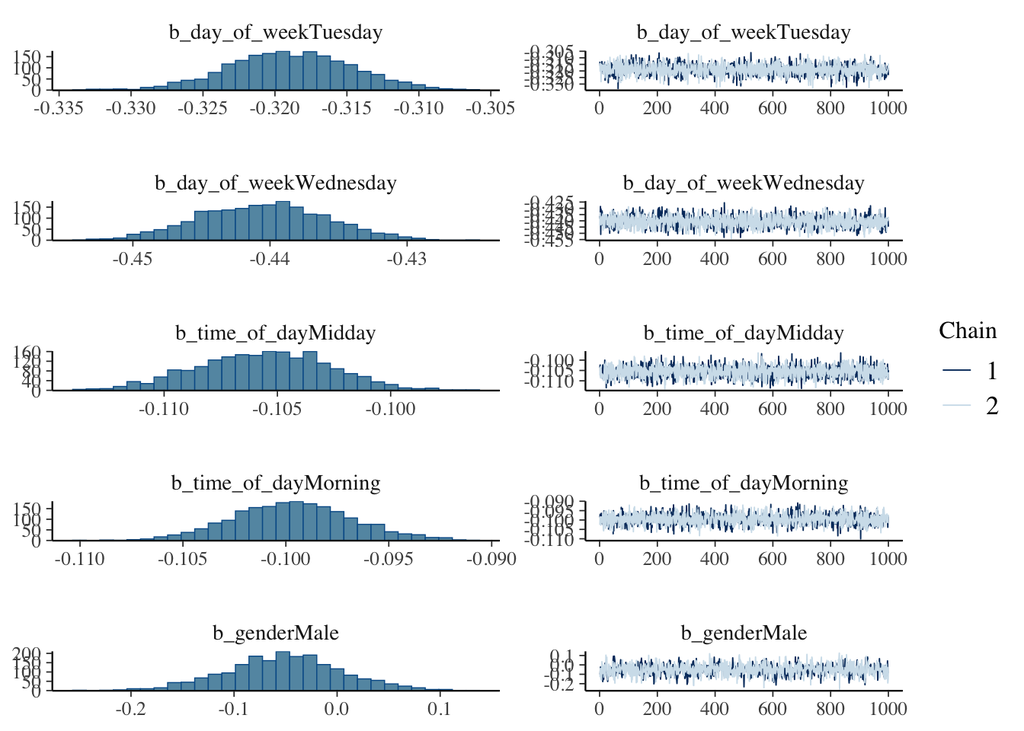

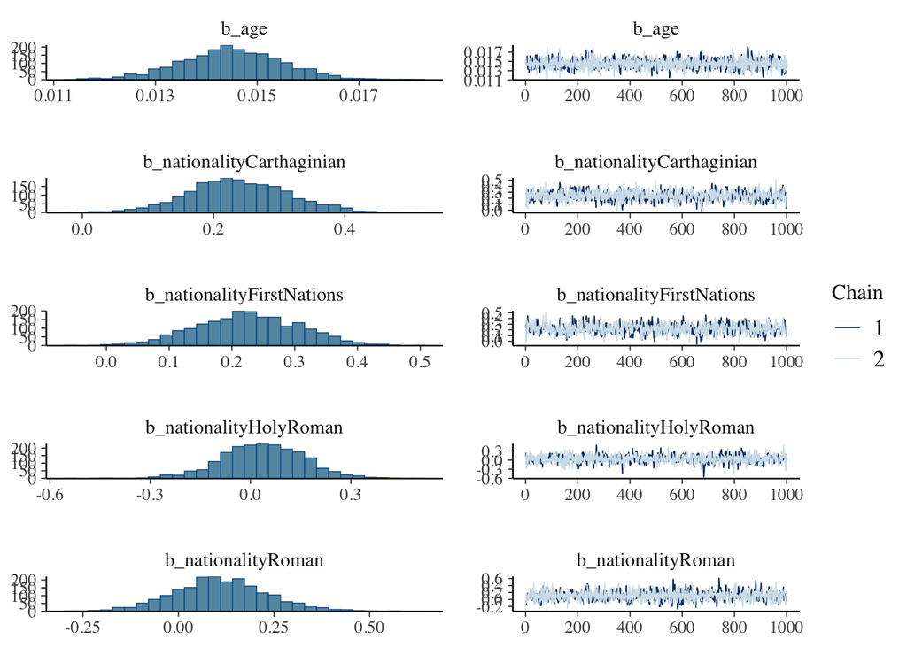

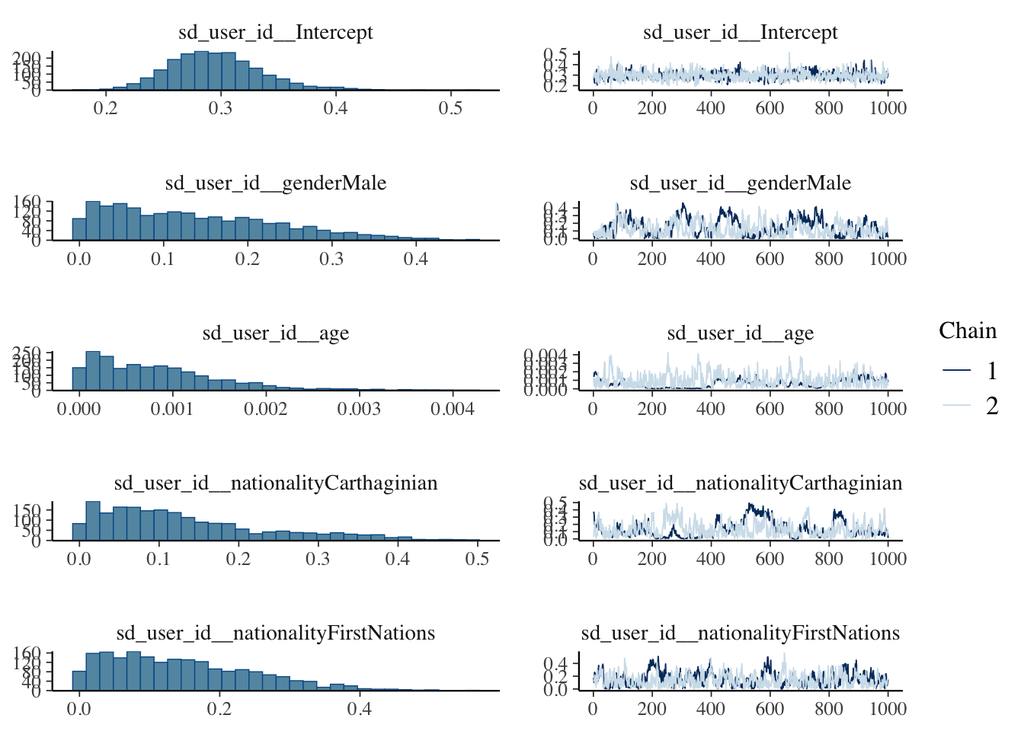

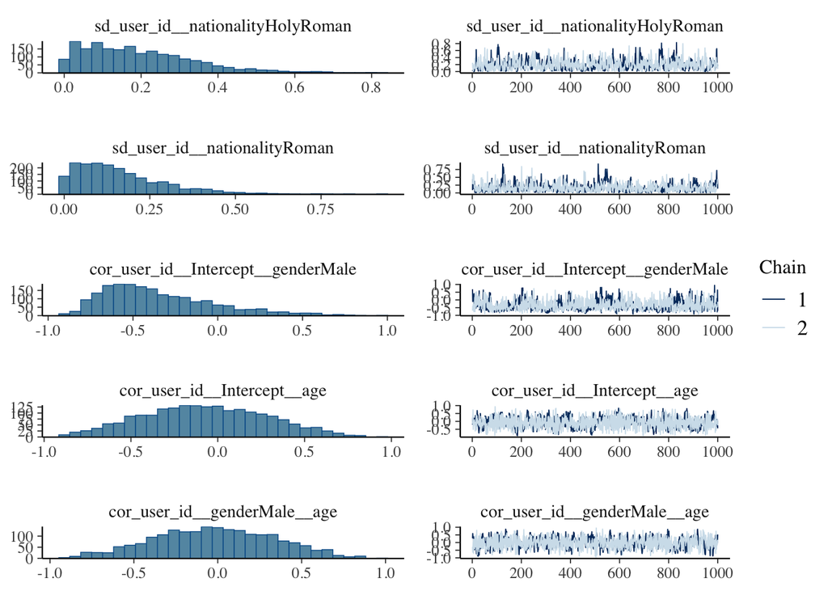

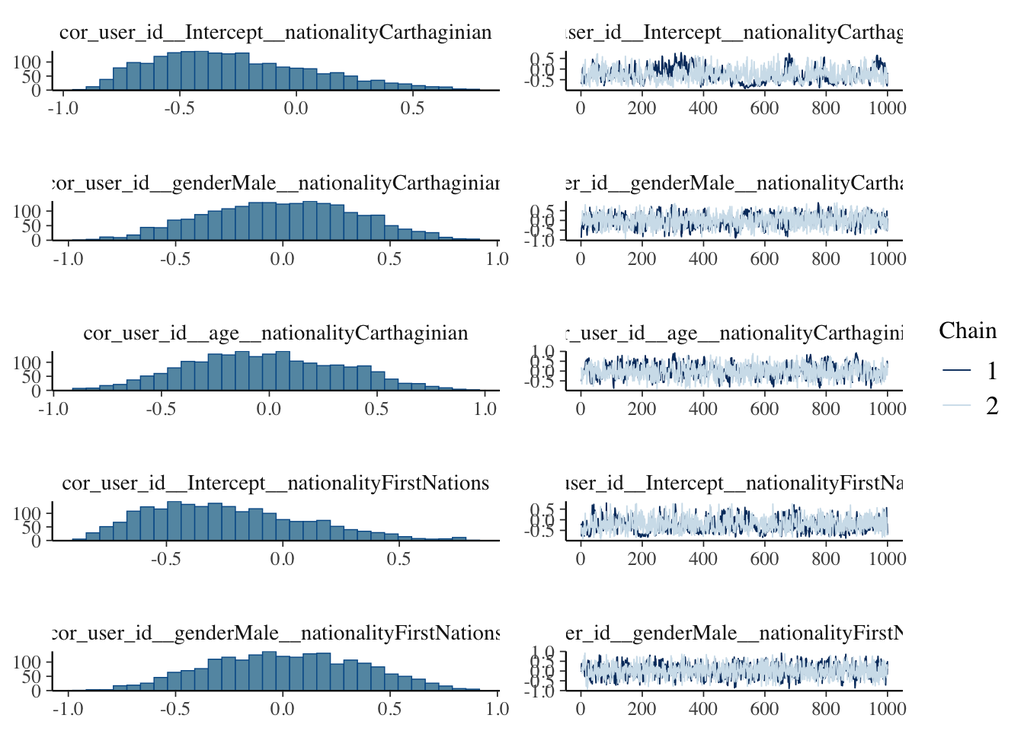

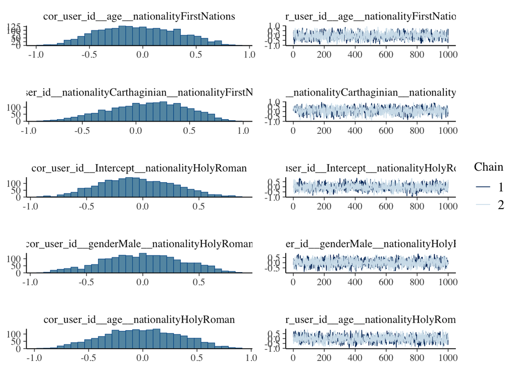

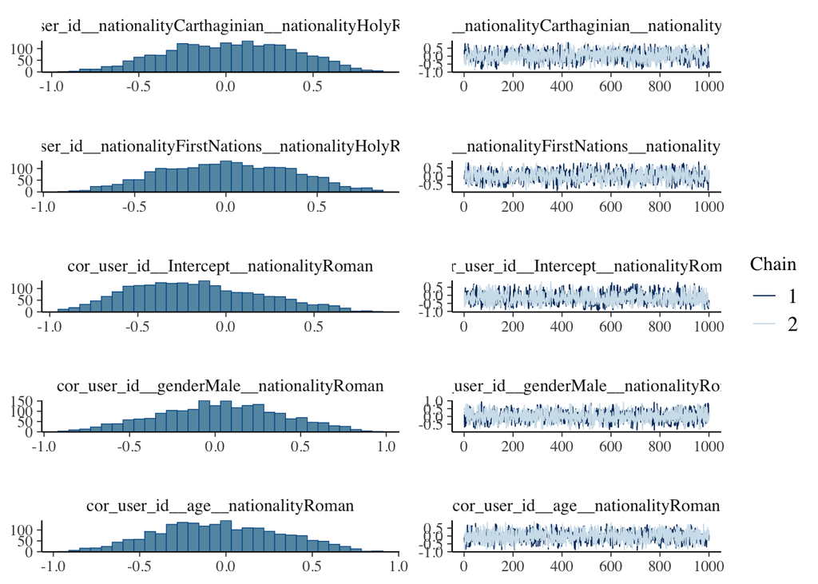

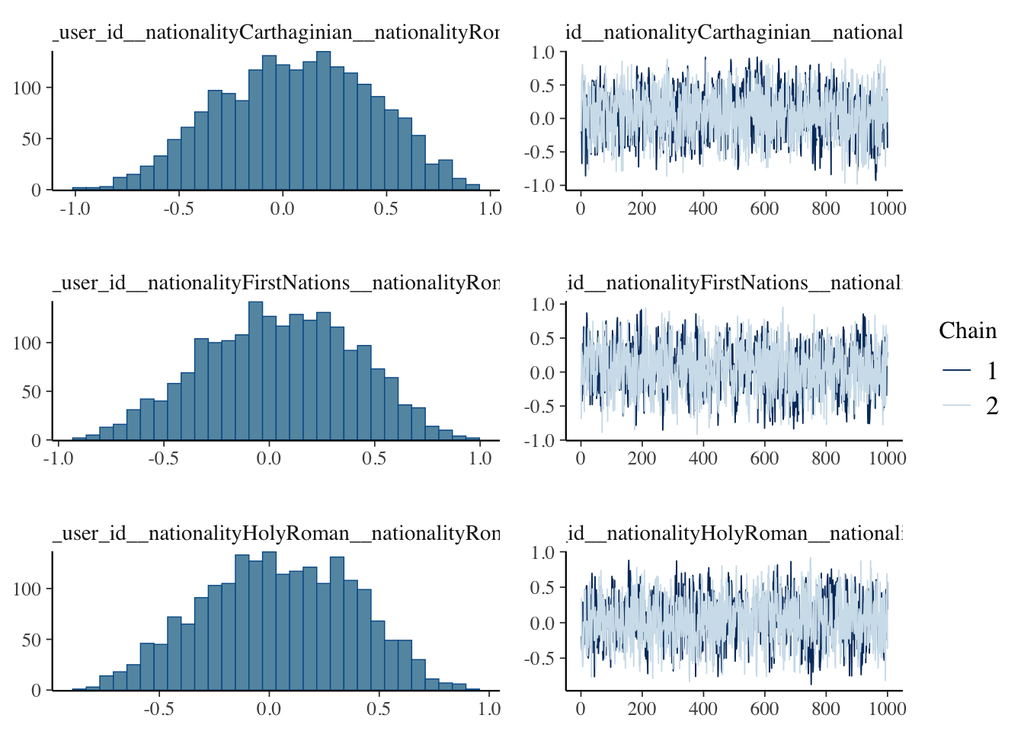

```r
plot(fit)
```

```r
pp_check(fit)
```

```
## Using 10 posterior draws for ppc type 'dens_overlay' by default.
```

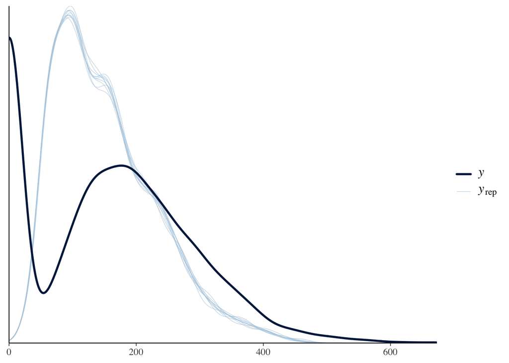